# Rapport — Detection de fraude bancaire

Type : Rapport d'analyse Date : 15/06/2026 Statut : Confidentiel

# Détection de fraude bancaire par Machine Learning

| **Module** | Machine Learning — Master 2 CDSD |
| --- | --- |
| **Auteur** | Steeve NGUEMA |

## Résumé exécutif

Presentation de la démarche complète de développement d'un système de détection automatique des transactions frauduleuses au sein d'une institution financière.

Face à un jeu de données fortement déséquilibré (~0,1 % de fraudes), nous appliquons une pipeline rigoureuse allant de l'analyse exploratoire jusqu'à l'interprétabilité des modèles, en passant par le prétraitement, la modélisation comparative et le suivi d'expériences MLflow.

**Objectif métier** : minimiser les fraudes non détectées (faux négatifs) tout en limitant les fausses alertes (faux positifs) qui dégradent l'expérience client.

## Table des matières

1. Initialisation et description des données
2. Analyse exploratoire des données (EDA)
3. Prétraitement
4. Modélisation
5. Évaluation et comparaison des modèles
6. Interprétabilité
7. Conclusion et recommandations

## Configuration de l'environnement

Chargement des librairies et des modules internes du projet.

## 1. Initialisation et description des données

### 1.1 Source des données

Le jeu de données est issu d'une simulation de transactions financières mobiles. Il contient les variables suivantes :

| Variable | Type | Description |
| --- | --- | --- |
| `step` | Entier | Unité temporelle de la transaction |
| `type` | Catégoriel | Type de transaction (PAYMENT, TRANSFER, CASH_OUT, DEBIT, CASH_IN) |
| `amount` | Continu | Montant transféré |
| `nameOrig` | Identifiant | Client émetteur |
| `oldbalanceOrg` | Continu | Solde émetteur avant transaction |
| `newbalanceOrig` | Continu | Solde émetteur après transaction |
| `nameDest` | Identifiant | Client destinataire |
| `oldbalanceDest` | Continu | Solde destinataire avant transaction |
| `newbalanceDest` | Continu | Solde destinataire après transaction |
| `isFraud` | Binaire | **Variable cible** — 1 = fraude, 0 = normale |
| `isFlaggedFraud` | Binaire | Signal du système existant (exclu de la modélisation) |

### 1.2 Initialisation

```
Dimensions : 1,048,575 lignes x 11 colonnes
```

|  | step | type | amount | nameOrig | oldbalanceOrg | newbalanceOrig | nameDest | oldbalanceDest | newbalanceDest | isFraud | isFlaggedFraud |
| --- | --- | --- | --- | --- | --- | --- | --- | --- | --- | --- | --- |
| 0 | 1 | PAYMENT | 9839.64 | C1231006815 | 170136.0 | 160296.36 | M1979787155 | 0.0 | 0.0 | 0 | 0 |
| 1 | 1 | PAYMENT | 1864.28 | C1666544295 | 21249.0 | 19384.72 | M2044282225 | 0.0 | 0.0 | 0 | 0 |
| 2 | 1 | TRANSFER | 181.00 | C1305486145 | 181.0 | 0.00 | C553264065 | 0.0 | 0.0 | 1 | 0 |
| 3 | 1 | CASH_OUT | 181.00 | C840083671 | 181.0 | 0.00 | C38997010 | 21182.0 | 0.0 | 1 | 0 |
| 4 | 1 | PAYMENT | 11668.14 | C2048537720 | 41554.0 | 29885.86 | M1230701703 | 0.0 | 0.0 | 0 | 0 |

```
Types des variables :
step                int64
type               object
amount            float64
nameOrig           object
oldbalanceOrg     float64
newbalanceOrig    float64
nameDest           object
oldbalanceDest    float64
newbalanceDest    float64
isFraud             int64
isFlaggedFraud      int64
dtype: object

Valeurs manquantes :
step              0
type              0
amount            0
nameOrig          0
oldbalanceOrg     0
newbalanceOrig    0
nameDest          0
oldbalanceDest    0
newbalanceDest    0
isFraud           0
isFlaggedFraud    0
dtype: int64
```

|  | step | amount | oldbalanceOrg | newbalanceOrig | oldbalanceDest | newbalanceDest | isFraud | isFlaggedFraud |
| --- | --- | --- | --- | --- | --- | --- | --- | --- |
| count | 1.048575e+06 | 1.048575e+06 | 1.048575e+06 | 1.048575e+06 | 1.048575e+06 | 1.048575e+06 | 1.048575e+06 | 1048575.0 |
| mean | 2.696617e+01 | 1.586670e+05 | 8.740055e+05 | 8.938049e+05 | 9.781600e+05 | 1.114193e+06 | 1.089097e-03 | 0.0 |
| std | 1.562325e+01 | 2.649409e+05 | 2.971725e+06 | 3.008246e+06 | 2.296779e+06 | 2.416554e+06 | 3.298351e-02 | 0.0 |
| min | 1.000000e+00 | 1.000000e-01 | 0.000000e+00 | 0.000000e+00 | 0.000000e+00 | 0.000000e+00 | 0.000000e+00 | 0.0 |
| 25% | 1.500000e+01 | 1.214907e+04 | 0.000000e+00 | 0.000000e+00 | 0.000000e+00 | 0.000000e+00 | 0.000000e+00 | 0.0 |
| 50% | 2.000000e+01 | 7.634333e+04 | 1.600200e+04 | 0.000000e+00 | 1.263772e+05 | 2.182604e+05 | 0.000000e+00 | 0.0 |
| 75% | 3.900000e+01 | 2.137619e+05 | 1.366420e+05 | 1.746000e+05 | 9.159235e+05 | 1.149808e+06 | 0.000000e+00 | 0.0 |
| max | 9.500000e+01 | 1.000000e+07 | 3.893942e+07 | 3.894623e+07 | 4.205466e+07 | 4.216916e+07 | 1.000000e+00 | 0.0 |

**Observations** : Le jeu de données ne présente aucune valeur manquante. Les montants (`amount`) varient fortement, justifiant une normalisation.

## 2. Analyse Exploratoire des Données (EDA)

L'analyse exploratoire vise à comprendre la structure du jeu de données, identifier les patterns caractéristiques des transactions frauduleuses, et orienter les choix de prétraitement.

### 2.1 Distribution de la variable cible

La variable cible `isFraud` est binaire. Son taux de fraude est attendu très faible, ce qui constitue le principal défi.

```
Taux de fraude : 0.1089%
isFraud
0    1047433
1       1142
Name: count, dtype: int64
```

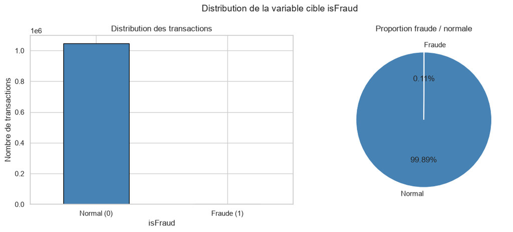

**Observation** : Le déséquilibre est extrême — les fraudes représentent moins de 0,2 % des transactions. L'accuracy ne peut pas être la métrique principale. Le **Recall** (taux de fraudes détectées) et le **F1-Score** sur la classe fraude seront les indicateurs de référence tout au long de l'analyse.

### 2.2 Répartition des fraudes par type de transaction

Certains types de transactions sont structurellement plus exposés à la fraude. Cette analyse permet d'identifier les canaux à risque.

```
    type  nb_fraudes  nb_total  taux_fraude  taux_fraude_pct
TRANSFER         564     86753     0.006501         0.650122
CASH_OUT         578    373641     0.001547         0.154694
 CASH_IN           0    227130     0.000000         0.000000
   DEBIT           0      7178     0.000000         0.000000
 PAYMENT           0    353873     0.000000         0.000000
```

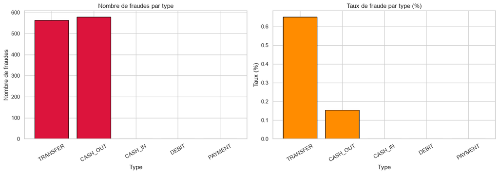

**Observation** : Les fraudes se concentrent exclusivement sur deux types de transactions : **CASH_OUT** (retrait) et **TRANSFER** (virement). Les types PAYMENT, DEBIT et CASH_IN ne présentent aucune fraude. Cette observation oriente directement la stratégie de surveillance opérationnelle.

### 2.3 Distribution des montants transactionnels

L'analyse des montants vise à déterminer si les transactions frauduleuses se distinguent des transactions normales par leur valeur financière.

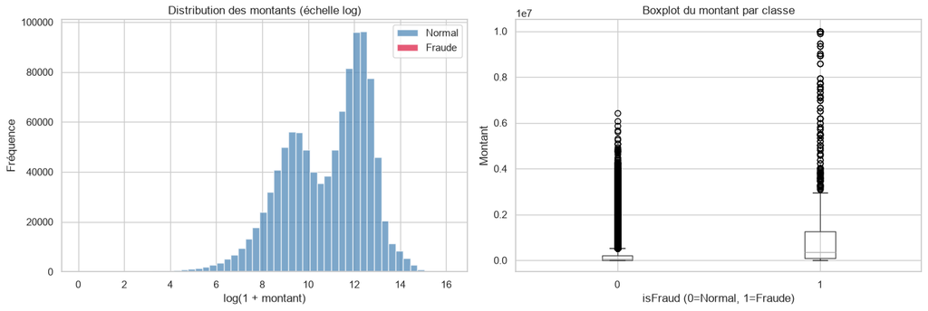

```
Statistiques du montant par classe :
             count          mean           std    min       25%        50%  \
isFraud
0        1047433.0  1.575397e+05  2.541883e+05    0.1  12134.87   76214.97
1           1142.0  1.192629e+06  2.030599e+06  119.0  86070.17  353179.45

                  75%          max
isFraud
0        2.134928e+05   6419835.27
1        1.248759e+06  10000000.00
```

### 2.4 Détection des comportements suspects

Les fraudes laissent souvent des traces dans les soldes des comptes. On recherche deux patterns typiques : le solde émetteur vidé à zéro et le solde destinataire inchangé après réception.

```
Fraudes avec solde émetteur à 0 : 1,133 (99.2% des fraudes)
Fraudes avec solde destinataire inchangé : 543 (47.5% des fraudes)

Statistiques des soldes pour les transactions frauduleuses :
       oldbalanceOrg  newbalanceOrig  oldbalanceDest  newbalanceDest
count   1.142000e+03    1.142000e+03    1.142000e+03    1.142000e+03
mean    1.218656e+06    3.394432e+04    4.528040e+05    1.077944e+06
std     2.229986e+06    5.012930e+05    1.661384e+06    2.434547e+06
min     0.000000e+00    0.000000e+00    0.000000e+00    0.000000e+00
25%     7.802889e+04    0.000000e+00    0.000000e+00    0.000000e+00
50%     3.487051e+05    0.000000e+00    0.000000e+00    1.379876e+04
75%     1.218166e+06    0.000000e+00    1.617654e+05    9.685277e+05
max     1.988782e+07    9.887819e+06    3.296166e+07    3.464570e+07
```

### 2.5 Matrice de corrélation

La matrice de corrélation permet d'identifier les relations linéaires entre variables numériques et la variable cible, et de détecter d'éventuelles colinéarités.

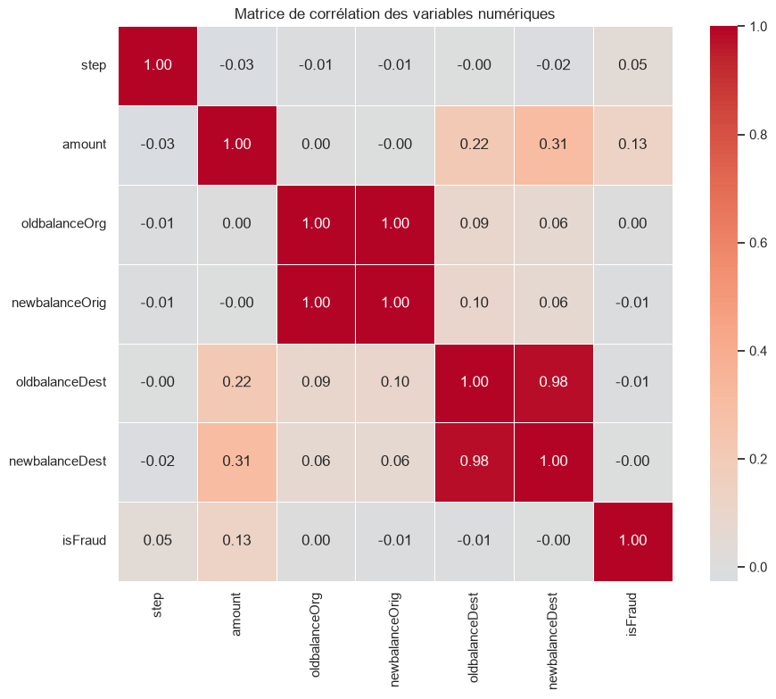

**Observation** : Les variables de soldes (`oldbalanceOrg`, `newbalanceOrig`) sont fortement corrélées entre elles, ce qui est attendu. La corrélation directe avec `isFraud` est faible pour toutes les variables brutes — ce qui confirme que la modélisation nécessite des variables dérivées pour capturer les patterns frauduleux.

**Synthèse EDA** : Les transactions frauduleuses se caractérisent par :

- un type exclusivement CASH_OUT ou TRANSFER
- des montants élevés
- des anomalies dans les soldes avant/après transaction. Ces éléments guident directement les choix de prétraitement.

## 3. Prétraitement

Le prétraitement suit un ordre strict pour éviter toute fuite d'information (*data leakage*) :

> Suppression → Feature Engineering → Encodage → Split → Normalisation → SMOTE

### 3.1 Suppression des colonnes non pertinentes

- `nameOrig` et `nameDest` : identifiants uniques sans pouvoir prédictif généralisable.
- `isFlaggedFraud` : variable de signal du système existant — l'inclure fausserait l'évaluation.

```
Dimensions après suppression : (1048575, 8)
```

### 3.2 Feature Engineering

Quatre variables synthétiques sont créées à partir des anomalies de soldes observées en EDA :

| Nouvelle variable | Formule | Signification |
| --- | --- | --- |
| `diff_solde_orig` | `oldbalanceOrg - newbalanceOrig` | Montant débité du compte émetteur |
| `diff_solde_dest` | `newbalanceDest - oldbalanceDest` | Montant crédité au destinataire |
| `erreur_solde_orig` | `diff_solde_orig - amount` | Écart entre débit réel et montant déclaré |
| `erreur_solde_dest` | `diff_solde_dest - amount` | Écart entre crédit réel et montant déclaré |

Un écart non nul sur `erreur_solde_orig` ou `erreur_solde_dest` signale une incohérence comptable caractéristique des fraudes.

```
Dimensions après feature engineering : (1048575, 12)
```

|  | diff_solde_orig | diff_solde_dest | erreur_solde_orig | erreur_solde_dest |
| --- | --- | --- | --- | --- |
| 0 | 9839.64 | 0.0 | 1.455192e-11 | -9839.64 |
| 1 | 1864.28 | 0.0 | -1.136868e-12 | -1864.28 |
| 2 | 181.00 | 0.0 | 0.000000e+00 | -181.00 |
| 3 | 181.00 | -21182.0 | 0.000000e+00 | -21363.00 |
| 4 | 11668.14 | 0.0 | 0.000000e+00 | -11668.14 |

### 3.3 Encodage de la variable `type`

```
Mapping type de transaction :
  CASH_IN → 0
  CASH_OUT → 1
  DEBIT → 2
  PAYMENT → 3
  TRANSFER → 4
```

### 3.4 Séparation X / y et split train / test

```
Train : 838,860 lignes  |  Test : 209,715 lignes
Fraudes train : 914 (0.109%)
Fraudes test  : 228 (0.109%)
```

### 3.5 Normalisation (StandardScaler)

Le `StandardScaler` centre et réduit chaque variable (moyenne = 0, écart-type = 1). Il est **ajusté uniquement sur les données d'entraînement** (`fit_transform`) puis appliqué sur le test (`transform`) pour ne pas introduire d'information du test dans la normalisation.

```
Normalisation appliquée (fit sur train, transform sur test).
```

### 3.6 Rééquilibrage des classes — SMOTE

**SMOTE** (Synthetic Minority Over-sampling Technique) génère des exemples synthétiques de la classe minoritaire (fraudes) par interpolation entre voisins proches dans l'espace des features. Il est appliqué **uniquement sur les données d'entraînement** — le jeu de test conserve la distribution réelle pour une évaluation non biaisée.

```
Avant SMOTE → Normal : 837,946  |  Fraude : 914
Après SMOTE → Normal : 837,946  |  Fraude : 837,946
```

**Synthèse prétraitement** : Le jeu d'entraînement est désormais équilibré, normalisé et enrichi de 4 variables synthétiques. Le jeu de test reste intact (distribution originale) pour garantir une évaluation représentative des conditions réelles de production.

## 4. Modélisation

Cinq algorithmes de classification sont comparés, allant du modèle linéaire de référence aux approches ensemblistes et aux réseaux de neurones :

| Modèle | Famille | Caractéristiques |
| --- | --- | --- |
| Régression Logistique | Linéaire | Modèle de référence, interprétable |
| Random Forest | Ensembliste (bagging) | Robuste, gère les non-linéarités |
| XGBoost | Ensembliste (boosting) | Haute performance, nativement compatible SHAP |
| LightGBM | Ensembliste (boosting) | Rapide, efficace sur données déséquilibrées |
| Réseau de Neurones | Deep Learning | Capture des patterns complexes |

Chaque entraînement est tracké avec **MLflow** (paramètres, métriques, modèle sauvegardé).

[output not shown]

```
Expérience MLflow initialisée.
```

### 4.1 Régression Logistique

[output not shown]

```
--- Régression Logistique ---
              precision    recall  f1-score   support

      Normal       1.00      0.96      0.98    209487
      Fraude       0.03      0.86      0.05       228

    accuracy                           0.96    209715
   macro avg       0.51      0.91      0.52    209715
weighted avg       1.00      0.96      0.98    209715
```

### 4.2 Random Forest

```
--- Random Forest ---
              precision    recall  f1-score   support

      Normal       1.00      1.00      1.00    209487
      Fraude       0.74      0.99      0.84       228

    accuracy                           1.00    209715
   macro avg       0.87      0.99      0.92    209715
weighted avg       1.00      1.00      1.00    209715
```

[output not shown]

### 4.3 XGBoost

[output not shown]

```
--- XGBoost ---
              precision    recall  f1-score   support

      Normal       1.00      1.00      1.00    209487
      Fraude       0.52      0.98      0.68       228

    accuracy                           1.00    209715
   macro avg       0.76      0.99      0.84    209715
weighted avg       1.00      1.00      1.00    209715
```

### 4.4 LightGBM

[output not shown]

```
--- LightGBM ---
              precision    recall  f1-score   support

      Normal       1.00      1.00      1.00    209487
      Fraude       0.68      0.98      0.80       228

    accuracy                           1.00    209715
   macro avg       0.84      0.99      0.90    209715
weighted avg       1.00      1.00      1.00    209715
```

### 4.5 Réseau de Neurones (TensorFlow / Keras)

Architecture MLP (Multi-Layer Perceptron) avec régularisation :

- **Couche 1** : 64 neurones, activation ReLU, BatchNormalization, Dropout 30 %
- **Couche 2** : 32 neurones, activation ReLU, BatchNormalization, Dropout 20 %
- **Sortie** : 1 neurone, activation Sigmoïde (probabilité de fraude)
- **Optimiseur** : Adam — **Loss** : Binary Crossentropy
- **Métriques surveillées** : AUC et Recall (pas l'accuracy)

[output not shown]

```
Model: "sequential"
```

```
┏━━━━━━━━━━━━━━━━━━━━━━━━━━━━━━━━━┳━━━━━━━━━━━━━━━━━━━━━━━━┳━━━━━━━━━━━━━━━┓
┃ Layer (type)                    ┃ Output Shape           ┃       Param # ┃
┡━━━━━━━━━━━━━━━━━━━━━━━━━━━━━━━━━╇━━━━━━━━━━━━━━━━━━━━━━━━╇━━━━━━━━━━━━━━━┩
│ dense (Dense)                   │ (None, 64)             │           768 │
├─────────────────────────────────┼────────────────────────┼───────────────┤
│ batch_normalization             │ (None, 64)             │           256 │
│ (BatchNormalization)            │                        │               │
├─────────────────────────────────┼────────────────────────┼───────────────┤
│ dropout (Dropout)               │ (None, 64)             │             0 │
├─────────────────────────────────┼────────────────────────┼───────────────┤
│ dense_1 (Dense)                 │ (None, 32)             │         2,080 │
├─────────────────────────────────┼────────────────────────┼───────────────┤
│ batch_normalization_1           │ (None, 32)             │           128 │
│ (BatchNormalization)            │                        │               │
├─────────────────────────────────┼────────────────────────┼───────────────┤
│ dropout_1 (Dropout)             │ (None, 32)             │             0 │
├─────────────────────────────────┼────────────────────────┼───────────────┤
│ dense_2 (Dense)                 │ (None, 1)              │            33 │
└─────────────────────────────────┴────────────────────────┴───────────────┘
```

```
 Total params: 3,265 (12.75 KB)
```

```
 Trainable params: 3,073 (12.00 KB)
```

```
 Non-trainable params: 192 (768.00 B)
```

```
6547/6547 ━━━━━━━━━━━━━━━━━━━━ 31s 4ms/step - auc: 0.9943 - loss: 0.0878 - recall: 0.9653 - val_auc: 0.9944 - val_loss: 0.0360 - val_recall: 0.9693
6547/6547 ━━━━━━━━━━━━━━━━━━━━ 24s 4ms/step - auc: 0.9971 - loss: 0.0616 - recall: 0.9744 - val_auc: 0.9929 - val_loss: 0.0514 - val_recall: 0.9737
6547/6547 ━━━━━━━━━━━━━━━━━━━━ 23s 3ms/step - auc: 0.9975 - loss: 0.0560 - recall: 0.9763 - val_auc: 0.9952 - val_loss: 0.0383 - val_recall: 0.9737
6547/6547 ━━━━━━━━━━━━━━━━━━━━ 22s 3ms/step - auc: 0.9978 - loss: 0.0531 - recall: 0.9773 - val_auc: 0.9950 - val_loss: 0.0357 - val_recall: 0.9737
6547/6547 ━━━━━━━━━━━━━━━━━━━━ 43s 4ms/step - auc: 0.9979 - loss: 0.0516 - recall: 0.9779 - val_auc: 0.9944 - val_loss: 0.0693 - val_recall: 0.9781
6547/6547 ━━━━━━━━━━━━━━━━━━━━ 25s 4ms/step - auc: 0.9980 - loss: 0.0504 - recall: 0.9784 - val_auc: 0.9954 - val_loss: 0.0335 - val_recall: 0.9693
6547/6547 ━━━━━━━━━━━━━━━━━━━━ 46s 5ms/step - auc: 0.9981 - loss: 0.0490 - recall: 0.9789 - val_auc: 0.9951 - val_loss: 0.0387 - val_recall: 0.9693
6547/6547 ━━━━━━━━━━━━━━━━━━━━ 48s 6ms/step - auc: 0.9981 - loss: 0.0482 - recall: 0.9790 - val_auc: 0.9933 - val_loss: 0.0394 - val_recall: 0.9737
6547/6547 ━━━━━━━━━━━━━━━━━━━━ 22s 3ms/step - auc: 0.9982 - loss: 0.0471 - recall: 0.9796 - val_auc: 0.9922 - val_loss: 0.0475 - val_recall: 0.9649
6547/6547 ━━━━━━━━━━━━━━━━━━━━ 27s 4ms/step - auc: 0.9982 - loss: 0.0466 - recall: 0.9799 - val_auc: 0.9929 - val_loss: 0.0253 - val_recall: 0.9518
6547/6547 ━━━━━━━━━━━━━━━━━━━━ 38s 4ms/step - auc: 0.9982 - loss: 0.0463 - recall: 0.9801 - val_auc: 0.9931 - val_loss: 0.0321 - val_recall: 0.9649
6547/6547 ━━━━━━━━━━━━━━━━━━━━ 24s 4ms/step - auc: 0.9983 - loss: 0.0453 - recall: 0.9805 - val_auc: 0.9931 - val_loss: 0.0432 - val_recall: 0.9781
6547/6547 ━━━━━━━━━━━━━━━━━━━━ 45s 4ms/step - auc: 0.9983 - loss: 0.0454 - recall: 0.9803 - val_auc: 0.9949 - val_loss: 0.0256 - val_recall: 0.9561
6547/6547 ━━━━━━━━━━━━━━━━━━━━ 37s 4ms/step - auc: 0.9983 - loss: 0.0448 - recall: 0.9806 - val_auc: 0.9950 - val_loss: 0.0319 - val_recall: 0.9737
6547/6547 ━━━━━━━━━━━━━━━━━━━━ 24s 4ms/step - auc: 0.9983 - loss: 0.0449 - recall: 0.9803 - val_auc: 0.9955 - val_loss: 0.0329 - val_recall: 0.9737
6547/6547 ━━━━━━━━━━━━━━━━━━━━ 26s 4ms/step - auc: 0.9983 - loss: 0.0449 - recall: 0.9805 - val_auc: 0.9952 - val_loss: 0.0268 - val_recall: 0.9737
6547/6547 ━━━━━━━━━━━━━━━━━━━━ 38s 3ms/step - auc: 0.9983 - loss: 0.0447 - recall: 0.9805 - val_auc: 0.9932 - val_loss: 0.0224 - val_recall: 0.9561
6547/6547 ━━━━━━━━━━━━━━━━━━━━ 54s 5ms/step - auc: 0.9983 - loss: 0.0443 - recall: 0.9807 - val_auc: 0.9930 - val_loss: 0.0184 - val_recall: 0.9386
6547/6547 ━━━━━━━━━━━━━━━━━━━━ 24s 4ms/step - auc: 0.9984 - loss: 0.0438 - recall: 0.9808 - val_auc: 0.9926 - val_loss: 0.0191 - val_recall: 0.9474
6547/6547 ━━━━━━━━━━━━━━━━━━━━ 39s 3ms/step - auc: 0.9984 - loss: 0.0434 - recall: 0.9808 - val_auc: 0.9931 - val_loss: 0.0446 - val_recall: 0.9737
6554/6554 ━━━━━━━━━━━━━━━━━━━━ 11s 2ms/step
```

[output not shown]

```
--- Réseau de Neurones ---
              precision    recall  f1-score   support

      Normal       1.00      0.99      0.99    209487
      Fraude       0.08      0.97      0.16       228

    accuracy                           0.99    209715
   macro avg       0.54      0.98      0.58    209715
weighted avg       1.00      0.99      0.99    209715
```

[output not shown]

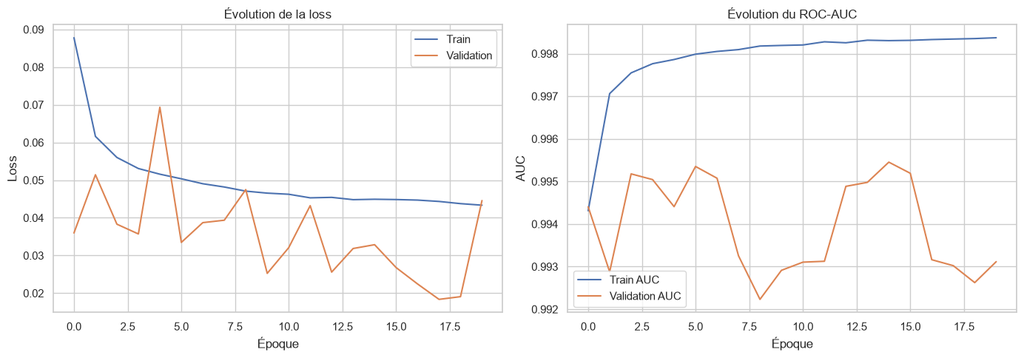

## 5. Évaluation et comparaison des modèles

### 5.1 Tableau comparatif des métriques

Les modèles sont classés par **F1-Score** sur la classe fraude. Les colonnes en vert indiquent la meilleure valeur par métrique.

```
Comparaison des modèles (triés par F1-Score) :
                       Accuracy  Precision  Recall  F1-Score  ROC-AUC
Modèle
Random Forest            0.9996     0.7377  0.9868    0.8443   0.9969
LightGBM                 0.9995     0.6767  0.9825    0.8014   0.9963
XGBoost                  0.9990     0.5210  0.9781    0.6799   0.9959
Réseau de Neurones       0.9885     0.0848  0.9737    0.1560   0.9962
Régression Logistique    0.9638     0.0251  0.8553    0.0488   0.9645
```

| Modèle | Accuracy | Precision | Recall | F1-Score | ROC-AUC |
| --- | --- | --- | --- | --- | --- |
| Random Forest | 0.999600 | 0.737700 | 0.986800 | 0.844300 | 0.996900 |
| LightGBM | 0.999500 | 0.676700 | 0.982500 | 0.801400 | 0.996300 |
| XGBoost | 0.999000 | 0.521000 | 0.978100 | 0.679900 | 0.995900 |
| Réseau de Neurones | 0.988500 | 0.084800 | 0.973700 | 0.156000 | 0.996200 |
| Régression Logistique | 0.963800 | 0.025100 | 0.855300 | 0.048800 | 0.964500 |

### 5.2 Courbes ROC

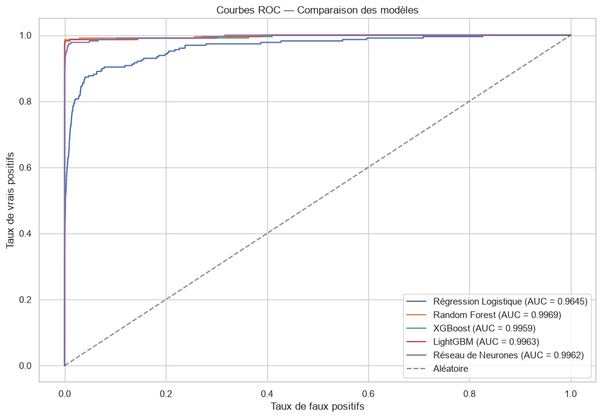

**Observation** : La courbe ROC mesure la capacité discriminante de chaque modèle indépendamment du seuil de classification. Un AUC proche de 1 indique un modèle quasi-parfait. Le modèle retenu sera celui combinant le meilleur AUC et le meilleur F1-Score.

### 5.3 Matrice de confusion — Meilleur modèle

La matrice de confusion décompose les erreurs de prédiction en quatre catégories : vrais positifs, vrais négatifs, faux positifs et faux négatifs.

```
Meilleur modèle : Random Forest
Modèle sauvegardé : ../donnees/traitees/meilleur_modele_fraude.pkl
```

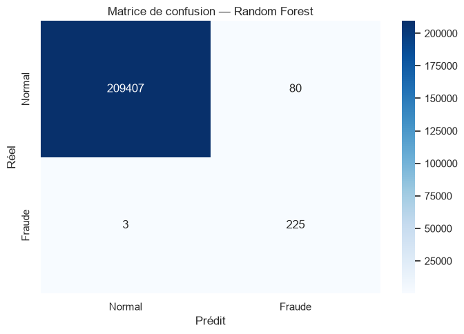

## 6. Interprétabilité

L'interprétabilité est essentielle dans le domaine financier pour justifier les décisions de blocage auprès des équipes métier et réglementaires. Deux niveaux d'analyse sont conduits :

- **Globale** : quelles variables influencent le plus les prédictions en général
- **Locale** : pourquoi le modèle a-t-il prédit fraude sur telle transaction spécifique

### 6.1 Importance des variables (XGBoost)

XGBoost calcule l'importance de chaque variable selon sa contribution à la réduction de l'impureté sur l'ensemble des arbres de décision.

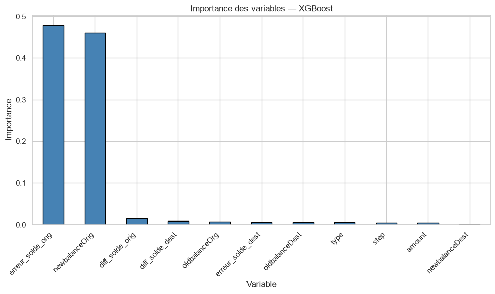

### 6.2 Analyse SHAP (SHapley Additive exPlanations)

SHAP est basé sur la théorie des jeux coopératifs. Il mesure la contribution marginale de chaque variable à chaque prédiction individuelle, garantissant une explication cohérente et fidèle au modèle.

- **Graphique bar** : importance globale (valeur absolue moyenne des SHAP)
- **Graphique beeswarm** : impact directionnel — rouge = valeur élevée de la variable, bleu = valeur faible

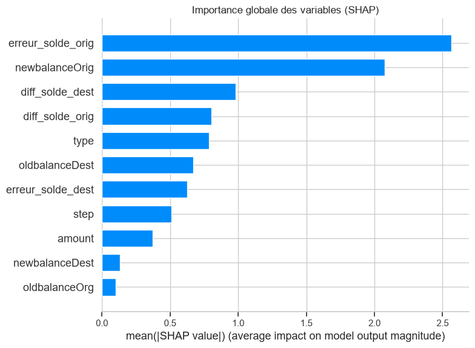

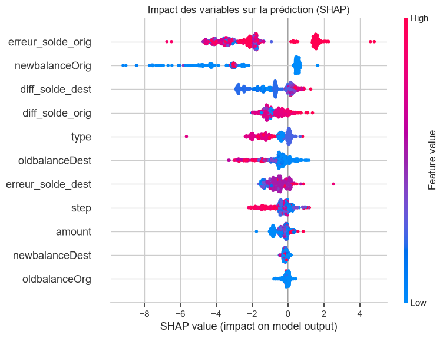

### 6.3 Analyse des erreurs de classification

Deux types d'erreurs ont des impacts métier distincts :

| Type d'erreur | Définition | Impact |
| --- | --- | --- |
| **Faux positif** | Transaction normale classée fraude | Blocage injustifié → friction client |
| **Faux négatif** | Fraude non détectée | Perte financière directe |

Dans le contexte bancaire, le **faux négatif est l'erreur la plus coûteuse**. L'analyse ci-dessous identifie le profil moyen des fraudes manquées.

```
Faux positifs (normales → fraude)     : 80
Faux négatifs (fraudes non détectées) : 3

Caractéristiques moyennes des faux négatifs (fraudes ratées) :
step                 2.533333e+01
type                 2.000000e+00
amount               5.832718e+05
oldbalanceOrg        2.531882e+04
newbalanceOrig       0.000000e+00
oldbalanceDest       3.165959e+06
newbalanceDest       3.749231e+06
diff_solde_orig      2.531882e+04
diff_solde_dest      5.832718e+05
erreur_solde_orig   -5.579530e+05
erreur_solde_dest    6.666667e-03
dtype: float64
```

## 7. Conclusion et recommandations

### 7.1 Bilan technique

| Étape | Choix technique | Justification |
| --- | --- | --- |
| Déséquilibre | SMOTE sur train uniquement | Préserve la distribution réelle du test |
| Feature engineering | 4 variables de soldes dérivées | Capturent les incohérences comptables des fraudes |
| Encodage | LabelEncoder sur `type` | Variable ordinale à faible cardinalité |
| Métrique principale | F1-Score + Recall (classe fraude) | L'accuracy est trompeuse sur données déséquilibrées |
| Tracking | MLflow | Reproductibilité et comparaison des expériences |

### 7.2 Recommandations opérationnelles

1. **Déploiement** : le modèle retenu sera exposé via une API FastAPI pour intégration dans le système transactionnel existant.
2. **Seuil de décision** : le seuil de 0,5 peut être ajusté selon la tolérance au risque. Abaisser le seuil augmente le Recall (moins de fraudes manquées) au détriment de la Precision (plus de faux positifs).
3. **Monitoring** : surveiller la dérive du taux de fraude détecté en production. Un changement de distribution des transactions (nouveau type de fraude, saisonnalité) peut dégrader les performances.
4. **Réentraînement** : planifier un réentraînement trimestriel avec les nouvelles transactions labelisées par les équipes fraude.
5. **Priorité de surveillance** : concentrer les efforts humains de vérification sur les transactions CASH_OUT et TRANSFER de montants supérieurs au percentile 75.

15/06/2026 | Usage interne — Diffusion restreinte